# EDA R1 CNBV

Jorge de la Vega

9 de agosto de 2018

## Datos

Los datos se obtienen de la página del portal del portafolio de informació financiera de la CNBV [Portafolio de información financiera](https://picomponentebi.cnbv.gob.mx/ReportViwer/ReportService?sector=40&tema=1&subTema=0&tipoInformacion=0&subTipoInformacion=0&idReporte=040_10a_R1&idPortafolio=0&idTipoReporteBI=1)

Primero hay que convertir los datos a una matriz de datos apropiada con el formato requerido. El archivo contiene dos partes con dos formatos diferentes. En ambos casos, hay que hacer manipulación de los datos para ponerlos en el formato que se requiere

```r
datos <- read.csv("../data/DatosCNBVR1.csv",header = T,skip = 1217)
head(datos)
```

```
  publicacion2 cve_periodo2 Textbox4 cve_item2                               Concepto1 item_Importe2 Flujo_Mes1
1  ABC Capital       201805    Monto        NA     Depósitos de Exigibilidad Inmediata        178.79      19.14
2  ABC Capital       201804    Monto        NA     Depósitos de Exigibilidad Inmediata        159.65      48.49
3  ABC Capital       201803    Monto        NA     Depósitos de Exigibilidad Inmediata        111.16    - 37.99
4  ABC Capital       201805    Monto        NA                       Depósitos a Plazo      3,414.90      18.64
5  ABC Capital       201804    Monto        NA                       Depósitos a Plazo      3,396.26       2.15
6  ABC Capital       201803    Monto        NA                       Depósitos a Plazo      3,394.11      51.36
```

En este formato, vemos que los datos están en formato *long*. Nos interesa analizar para cada banco los diferentes conceptos.

```r
library(tidyverse)
datos2 <- datos %>%  select(-c(Textbox4,cve_item2,Flujo_Mes1)) %>%
          filter(cve_periodo2=="201805") %>%
          spread(Concepto1, item_Importe2) %>%
          select(-cve_periodo2)
head(datos2)
```

```
      publicacion2         Del Público en General         Mercado de Dinero     Depósitos a Plazo     Depósitos de Exigibilidad Inmediata     Títulos de Crédito Emitidos
1      ABC Capital                       3,414.90                      0.00              3,414.90                                  178.79                            0.00
2    Accendo Banco                       1,327.67                    951.30              2,278.96                                  703.04                            0.00
3         Actinver                       5,321.45                  7,880.63             13,202.09                                6,668.34                        2,206.69
4           Afirme                      16,319.19                    478.97             16,798.16                               26,069.37                        3,554.31
5 American Express                       2,652.46                                        2,652.46                                  109.28
6          Autofin                       1,858.64                  1,799.55              3,658.19                                  340.16                            0.00
```

Conviene renombrar los nombres de las variables para poder manipularlas mejor

```r
names(datos2) <- c("inst","dep_pubgen","mdo_din","dep_plazo","dep_exi","tit_cred")
head(datos2)
```

```
              inst dep_pubgen  mdo_din dep_plazo   dep_exi tit_cred
1      ABC Capital   3,414.90     0.00  3,414.90    178.79     0.00
2    Accendo Banco   1,327.67   951.30  2,278.96    703.04     0.00
3         Actinver   5,321.45 7,880.63 13,202.09  6,668.34 2,206.69
4           Afirme  16,319.19   478.97 16,798.16 26,069.37 3,554.31
5 American Express   2,652.46           2,652.46    109.28
6          Autofin   1,858.64 1,799.55  3,658.19    340.16     0.00
```

```r
datos <- as.data.frame(apply(datos2[,-1], 2, function(x)as.numeric(gsub(pattern=",",replacement="",x,fixed = TRUE))))
row.names(datos) <- datos2$inst
head(datos)
```

```
                 dep_pubgen mdo_din dep_plazo  dep_exi tit_cred
ABC Capital         3414.90    0.00   3414.90   178.79     0.00
Accendo Banco       1327.67  951.30   2278.96   703.04     0.00
Actinver            5321.45 7880.63  13202.09  6668.34  2206.69
Afirme             16319.19  478.97  16798.16 26069.37  3554.31
American Express    2652.46      NA   2652.46   109.28       NA
Autofin             1858.64 1799.55   3658.19   340.16     0.00
```

Antes de continuar hay que notar que algunos de los renglones de la matriz de datos corresponden a operaciones agregadas de ciertos subconjuntos de instituciones bancarias que hay que eliminar porque no corresponden a unidades experimentales. Por ejemplo, hay un registro que corresponde al “Total Banca Múltiple”, otro a “Santander Consolidado”, etc.

Además algunas instituciones no realizan operaciones de captación (o no reportan sus datos a la CNBV), como GE Money, Ixe (que se fusionó con Banorte), ING, etc.

También valdría la pena evaluar si se realiza un análisis excluyendo a bancos que reportan varios de los conceptos en cero, como Deutsche Bank. En este ejercicio se dejan a esos bancos para resaltar algunos puntos relevantes del análisis.

Por último, también hay que tener una idea de los conceptos relacionados con los atributos que se están midiendo. Los datos en las columnas están relacionados contablemenete: Los depósitos a plazo son la suma de los depósitos del publico en general más los depósitos por mercado de dinero:

$${\tt dep\_plazo} = {\tt dep\_pubgen} + {\tt mdo\_din}$$

Lo anterior se puede comprobar de la siguiente manera:

```r
with(datos,sum((dep_plazo-(dep_pubgen+mdo_din))^2,na.rm=T))
```

```
[1] 0.0018
```

Entonces es necesario eliminar una columna para evitar multicolinearidad en la matriz de datos. Se eliminará el agregado.

```r
datos <- datos[,-3]
```

Eliminando estos registros nos queda la matriz de datos para comenzar el análisis

```r
#renglones a eliminar de la matriz:
nombres <- row.names(datos)
l <- c(grep("Consolidado",nombres),grep("G-7",nombres),grep("Servicios",nombres),
       grep("Comercial",nombres),grep("Total Banca",nombres),grep("Créditos a los Hogares",nombres),
       grep("Bicentenario",nombres),grep("Deuno",nombres),grep("Wal-Mart",nombres),
       grep("ING",nombres),grep("Ixe",nombres),grep("Wal-Mart",nombres),grep("GE Money",nombres),grep("New York Mellon",nombres),
       grep("UBS",nombres))
bancos <- datos[-l,]
bancos
```

```
                      dep_pubgen  mdo_din   dep_exi tit_cred
ABC Capital              3414.90     0.00    178.79     0.00
Accendo Banco            1327.67   951.30    703.04     0.00
Actinver                 5321.45  7880.63   6668.34  2206.69
Afirme                  16319.19   478.97  26069.37  3554.31
American Express         2652.46       NA    109.28       NA
Autofin                  1858.64  1799.55    340.16     0.00
Banamex                101811.76 66960.41 549312.58  6840.06
Banca Mifel             16721.07  2030.54  11944.44   288.89
Banco Ahorro Famsa      21006.08   341.04   5699.10     0.00
Banco Azteca            13098.82  1421.73  96447.24     0.00
Banco Bancrea            6010.41  1202.81    713.66     0.00
Banco Base               3136.99  4878.01   5055.78   709.64
Banco Credit Suisse       903.42  7875.16      0.00     0.00
Banco del Bajío         47905.90 18967.04  57012.23     0.00
Banco Pagatodo              0.00     0.00      7.92     0.00
Banco Sabadell           5003.09     0.00   6430.98     0.00
BanCoppel                2238.73     0.00  47528.56     0.00
Bancos Cambiarios       46758.22  7405.69  45069.44  2879.30
Bank of America           472.55       NA  14239.99       NA
Bankaool                    0.00     0.00      0.00     0.00
Banregio                46174.13  1123.34  32822.94     0.00
Bansí                   10114.78   256.18   1686.50     0.00
Barclays                    0.00     0.00      0.00     0.00
BBVA Bancomer          213773.79 19555.49 830248.64 84901.81
BTMU Mexico              6236.53     0.00  14774.21     0.00
CIBanco                 17202.95     0.00  12533.51     0.00
Compartamos              1196.68     0.00    997.76  7549.92
Consubanco                277.99  2077.43     86.15  2511.93
Deutsche Bank               0.00     0.00      1.45     0.00
Dondé Banco               231.74     0.00     18.85     0.00
Finterra                  103.05   238.75     32.96     0.00
Forjadores                206.28     0.00      0.00     0.00
HSBC                   102617.91 16546.61 235163.75 10195.54
ICBC                      375.31     0.00    177.42     0.00
Inbursa                 27326.12   459.47 109277.70 79355.10
Inmobiliario Mexicano    2821.45     0.00    237.31   140.43
Interacciones            6688.29 15314.71  68313.80 14638.70
Intercam Banco           8890.15   602.69   5226.21     0.00
Invex                    6304.80  8388.49   5972.23  1504.25
J.P. Morgan                 0.00     0.00  11352.79     0.00
Mizuho Bank              1156.38    10.05    453.67     0.00
Monex                   17528.12  1924.98  22253.95  2169.65
Multiva                 29140.13 17521.68  17725.08  4509.91
Santander              177853.09 50028.23 442833.93 51050.65
Scotiabank             101937.76 31816.30 160988.47 28575.83
Ve por Más               5831.65   752.62  18305.33  1496.37
Volkswagen Bank          1198.61     0.00    134.02  1000.68
```

## Estadísticas sumarias:

```r
summary(bancos)
```

```
   dep_pubgen        mdo_din           dep_exi            tit_cred
 Min.   :     0   Min.   :    0.0   Min.   :     0.0   Min.   :    0
 1st Qu.:  1030   1st Qu.:    0.0   1st Qu.:   178.1   1st Qu.:    0
 Median :  5321   Median :  602.7   Median :  5972.2   Median :    0
 Mean   : 23003   Mean   : 6418.0   Mean   : 60960.6   Mean   : 6802
 3rd Qu.: 17366   3rd Qu.: 7405.7   3rd Qu.: 29446.2   3rd Qu.: 2512
 Max.   :213774   Max.   :66960.4   Max.   :830248.6   Max.   :84902
                  NA's   :2                            NA's   :2
```

- El rango de variación entre el valor mínimo y el más grande indica que los datos pueden transformarse a la escala logarítmica para poder tener un mejor manejo, aunque la interpretación de los resultados pueda cambiar. Para evitar los ceros en el logaritmo, se puede agregar el valor 1 a la transformación.

```r
bancos <- log(bancos + 1)
```

Podemos ver la distribución de cada variable transformada en un histograma.

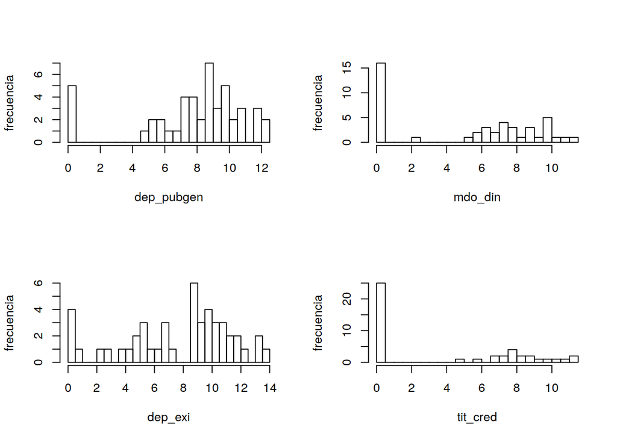

```r
par(mfrow=c(2,2))
for(i in 1:4){
  hist(bancos[,i],xlab=colnames(bancos)[i],ylab="frecuencia",main="",breaks=20)
}
```

Para identificar algunas relaciones entre las variables, se puede incluir una matriz de gráficas de dispersión

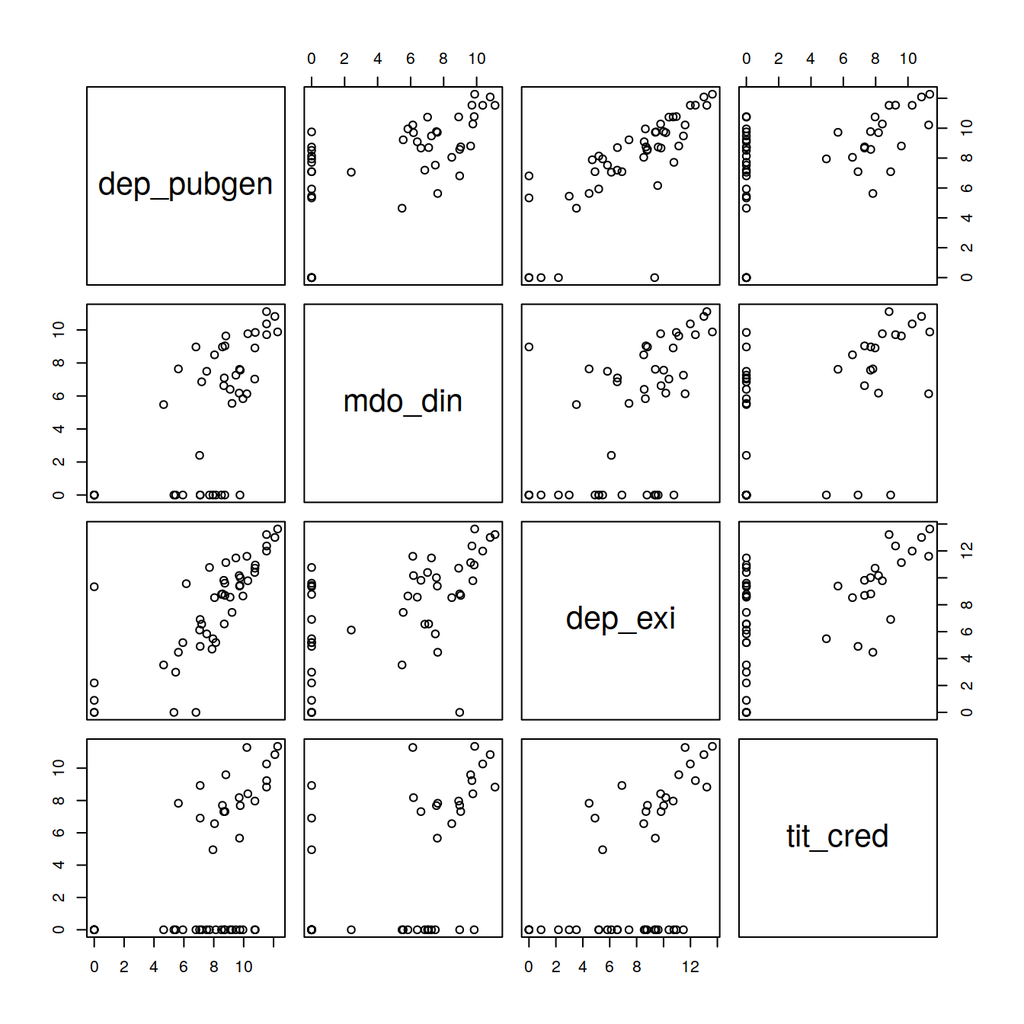

```r
pairs(bancos)
```

Evaluando el vector de medias, la matriz de covarianzas y la matriz de correlaciones. Como la matriz tiene datos faltantes, no podemos usar las fórmulas matriciales, pero las funciones que están definidas.

```r
n <- dim(bancos)[1]
xbar <-apply(bancos,2,mean,na.rm=T)
xbar
```

```
dep_pubgen    mdo_din    dep_exi   tit_cred
  7.762387   5.081954   7.644710   3.706805
```

```r
S <- var(bancos,na.rm=T)
S
```

```
           dep_pubgen   mdo_din   dep_exi  tit_cred
dep_pubgen  11.073939  8.966677 10.176298  7.275809
mdo_din      8.966677 16.995522  9.134674 10.038017
dep_exi     10.176298  9.134674 14.729788  9.226262
tit_cred     7.275809 10.038017  9.226262 18.879054
```

```r
R <- cor(bancos,use="pairwise")
R
```

```
           dep_pubgen   mdo_din   dep_exi  tit_cred
dep_pubgen  1.0000000 0.6536017 0.7811981 0.5031994
mdo_din     0.6536017 1.0000000 0.5773346 0.5603902
dep_exi     0.7811981 0.5773346 1.0000000 0.5532703
tit_cred    0.5031994 0.5603902 0.5532703 1.0000000
```

Bubble plot: (hasta tres variables)

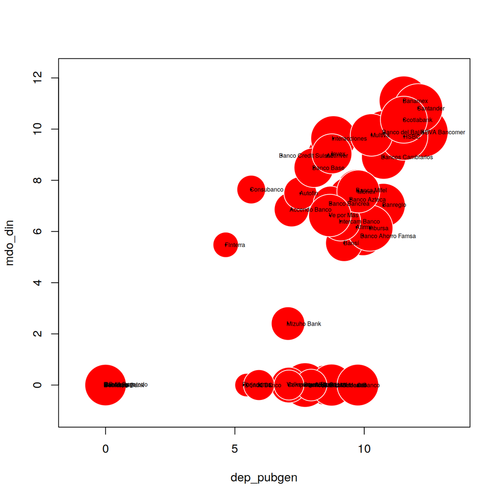

```r
radio <- sqrt( bancos$dep_exi/ pi ) #escalado a área correcta.
with(bancos,symbols(dep_pubgen,mdo_din,circles=radio,inches = 0.35,fg="white", bg="red"))
with(bancos,points(dep_pubgen,mdo_din,type="p",cex=0.2))
with(bancos,text(dep_pubgen,mdo_din,row.names(bancos),cex=0.5,offset = 0.1,adj=0.05))
```

Gráficas de estrella:

[figure not shown]

```r
stars(bancos,key.loc=c(0,0))
```